# Alien plant species

[NO_ALIE_002] (mountains)  
[NO_ALIE_003] (wetlands)  
[NO_ALIE_004] (forests)  
[NO_ALIE_005] (farmland and open lowland)

Authors

Affiliation

Joachim Töpper

Norwegian Institute for Nature Research

Erik Framstad

Norwegian Institute for Nature Research

Published

June 2, 2025

> **Recommended citation**: Töpper, J. and Framstad, E. 2025. Alien plant species (ID(s): NO_ALIE_002-005) v. 000.002. ecRxiv: https://github.com/NINAnor/ecRxiv/tree/main/indicators/NO_ALIE_002-005

**Metadata**

Table 1: Indicator metadata

| Variable | Value |
| --- | --- |
| Indicator ID | NO_ALIE_002; NO_ALIE_003; NO_ALIE_004; NO_ALIE_005 |
| Indicator Name | Alien plant species |
| Country | Norway |
| Continent | Europe |
| Ecosystem Condition Typology Class | B1 - Compositional State Characteristics |
| Realm | Terrestrial; Freshwater-Terrestrial (TF); Terrestrial; Terrestrial |
| Biome | T6 Polar-alpine (cryogenic) biome; TF1 Palustrine wetlands biome; T2 Temperate-boreal forests and woodlands biome; T3 Shrublands and shrubby woodlands biome; T4 Savannas and grasslands biome; T7 Inten… |
| Ecosystem |  |
| Year added | 2025 |
| Last update | 2025 |
| Version | 000.002 |
| Version comment | Similar to version 000.001, but with open science badges and some restructuring. Status set to operational. |
| Normalised | TRUE |
| Spatial aggregation pathway | [Scale-Transform] - Aggregate |

**Log**

- 09 Apr. 2025 - Original PR
- 02 Jun. 2025 - Code review complete.
- 21 Nov. 2025 - Restructure and adding badges (ALK)

## 2. About the underlying data

Here, we evaluate the ’Alien plant species’indicator based on field sampled plant community data from the Norwegian nature monitoring program ANO (Tingstad et al. 2019).

### 2.1 Spatial and temporal resolution and extent

The ANO monitoring data available now represent one cycle of sampling from 2019-2024 comprising ca. 1000 sites across Norway. ANO has no defined end date. 2025 is the first year of repeated sampling for about 20% of the approximately 1000 ANO sites for all of mainland Norway (i.e. the Ecosystem Accounting Area). Annual sampling is spatially representative, in principle allowing to compute area-representative estimates for single years but also 3-yr-reporting periods.

### 2.2 Original units

Abundance data for alien plant species in ANO is given as % cover within a 250 m<sup>2</sup> sample circle following the national alien species list (Artsdatabanken 2023).

### 2.3 Additional comments about the dataset

The ANO program is run by the Norwegian Environment Agency. On their web sites you may also find some additional summary data. https://www.miljodirektoratet.no/ansvarsomrader/overvaking-arealplanlegging/miljoovervaking/overvakingsprogrammer/natur-pa-land/arealrepresentativ-naturovervakning-ano/

#### 2.3.1 Instructions for citing, using and accessing data

ANO data are available from Kartkatalogen on the webpages of the Norwegian Environment Agency (as used here, https://kartkatalog.miljodirektoratet.no/Dataset/Details/2054) and via GBIF (https://doi.org/10.15468/4wc9r4).

## 3. Indicator properties

### 3.1 Ecosystem Condition Typology Class (ECT)

The ‘Alien plant species’ indicator reflect the plant species composition and thus represent ECT class ‘B1 Biotic compositional characteristics’.

### 3.2 Ecosystem condition characteristic

The ‘Alien plant species’ indicator addresses both the ecosystem characteristic ‘functionally important species and biophysical structures’ and ‘biological diversity’ in the Norwegian framework for ecological condition. The indicator has been linked solely to the former in the previous assessments of ecological condition in forest and mountain ecosystems.

### 3.3 Other standards

In the Norwegian “Fagsystem for økologisk tilstand” (Nybø and Evju 2017) the indicator is sorted under “Funksjonelt viktige arter og strukturer”.

### 3.4 Collinearities with other indicators

None.

### 3.5 Impact factors

The main impact factor for this indicator is the introduction of alien species. In addition, the spreading of introduced alien species can be enforced by climate change if it relaxes climatic limitation on them.

## 4. Reference condition and levels

### 4.1 Reference condition

In Norway, the reference condition for natural ecosystems has been one of largely intact ecosystems without large-scale human modifications (Nybø and Evju 2017). For semi-natural ecosystems, human influence is allowed, and indeed a prerequisite, but then in the sense of appropriate, stable and traditional land-use practices. Thus, in terms of alien species, the reference condition is defined as an ecosystem without any alien plant species.

### 4.2 Reference levels

X<sub>100</sub>: 100% of the monitoring site area without alien plant species.

X<sub>0</sub>: 0% area without alien plant species (see also Framstad et al. 2022 for implementations of this indicator in previous condition assessments for Norwegian forest and mountain ecosystems).

#### 4.2.1 Spatial resolution and validity

The same reference levels apply to all types of ecosystems and all regions.

## 5. Uncertainties

Uncertainties relate partly to sampling and observer variability (and possible observer bias) in the recording of the plant cover data. Spatial variability as a source of uncertainty can be quantified. For every mean or median indicator value (after scaling) for every region (or any other delimited area of interest) we can calculate its corresponding standard error or confidence interval quantiles as a measure of spatial uncertainty for a geographical area.

## 6. References

Artsdatabanken (2023, 11. august). Fremmede arter i Norge - med økologisk risiko 2023. http://www.artsdatabanken.no/lister/fremmedartslista/2023.

Framstad, E., Kolstad, A. L., Nybø, S., Töpper, J. & Vandvik, V. 2022. The condition of forest and mountain ecosystems in Norway. Assessment by the IBECA method. NINA Report 2100. Norwegian Institute for Nature Research.

Nybø, S. & Evju, M. (red.) 2017. Fagsystem for fastsetting av god økologisk tilstand. Forslag fra et ekspertråd, https://regjeringen.no/no/dokument/rapportar-og-planar/id438817/.

Tingstad, L., Evju, M., Sickel, H., & Töpper, J. 2019. Utvikling av nasjonal arealrepresentativ naturovervåking (ANO). Forslag til gjennomføring, protokoller og kostnadsvurderinger med utgangspunkt i erfaringer fra uttesting i Trøndelag. NINA Rapport 1642.

## 7. Datasets

### 7.1 ANO monitoring data

ANO stands for areal-representativ naturovervåking, i.e. area representative nature monitoring. 1000 sites are randomly distributed across mainland Norway and visited within a 5-year cycle. Each ANO site spans a 500 x 500 m grid cell, and the data collection at each ANO site includes up to 18 evenly distributed 250 sqm monitoring circles (up to 18, because some of these evenly distributed points may be in water or otherwise inaccessible). The combined cover of all alien plant species in the circle is recorded, in addition to the ecosystem the circle lies in, including ecosystem type and some additional variables related to ecosystem-specific drivers of state. In the analyses described in this document, we use the data available on Miljødirektoratets kartkatalog (https://kartkatalog.miljodirektoratet.no/Dataset/Details/2054), which comprises data from the first round of data collection in ANO, 2019-2024, and a total of 18 871 circles in 1052 sites. The timeframe of six years from 2019-2024 allows to create indicator values for the two 3-year reporting periods 2019-2021 and 2022-2024.

## 8. Spatial units

The spatial units for the ‘Alien plant species’ indicator are governed by the ANO data, which consist of 1000 randomly chosen sites in Norway. Each site is a 500 x 500 m grid cell with 18 monitoring circles of 250sqm and a central 1 x 1 m vegetation plot. The basic unit for which observational alien plant species abundance data exist, and for which every the ‘area without alien plant species’ indicator is computed, is the 250sqm circle. Aggregation of these basic spatial units to higher ones - like sites, municipalities, counties, regions, or the national level - should be done with appropriate consideration of the spatial structure of the data, i.e. imbalances and clustering (highly unequal number of points of an ecosystem type between sites).

## 9. Analyses

Import ANO testing data: First, download from from Miljødirektoratet…

```r
# download
url <- "https://nedlasting.miljodirektoratet.no/naturovervaking/naturovervaking_eksport.gdb.zip"
download(url, dest="P:/41201785_okologisk_tilstand_2022_2023/data/ANO/naturovervaking_eksport.gdb.zip", mode="wb")
unzip("P:/41201785_okologisk_tilstand_2022_2023/data/ANO/naturovervaking_eksport.gdb.zip", exdir = "P:/41201785_okologisk_tilstand_2022_2023/data/ANO/naturovervaking_eksport.gdb")
```

…then upload from local storage.

The geodatabase contains two relevant layers; one for the species data (ANO_Art) and one for the spatial data (ANO_SurveyPoint). These then can later be combined into one dataset if needed.

```r
#Sys.setlocale("LC_ALL", "no_NB.utf8") #works with æøå or use "Norwegian"
ANO.sp <- st_read("P:/41201785_okologisk_tilstand_2022_2023/data/ANO/naturovervaking_eksport.gdb",
                    layer="ANO_Art", quiet = T)
ANO.geo <- st_read("P:/41201785_okologisk_tilstand_2022_2023/data/ANO/naturovervaking_eksport.gdb",
                   layer="ANO_SurveyPoint", quiet = T)
#head(ANO.sp)
#head(ANO.geo)
```

#### Data handling

First we need to do some data handling. Most importantly we need to group NiN main types (e.g. T4, T30 etc.) into main ecosystem types (i.e. forest, mountain, wetland, semi-natural or naturally open).

```r
#### ANO monitoring data

#head(ANO.sp)
#head(ANO.geo)

## fix NiN information
ANO.geo$hovedtype_rute <- substr(ANO.geo$kartleggingsenhet_1m2,1,3) # take the 3 first characters
ANO.geo$hovedtype_rute <- gsub("-", "", ANO.geo$hovedtype_rute) # remove hyphen
unique(as.factor(ANO.geo$hovedtype_rute))

ANO.geo$hovedoekosystem_rute <- ANO.geo$hovedtype_rute
ANO.geo <- ANO.geo %>% mutate(hovedoekosystem_rute = recode(hovedoekosystem_rute,
  "T4" = "Forest", "T30" = "Forest",
  "T3" = "Mountain", "T7" = "Mountain", "T14" = "Mountain", "T22" = "Mountain",
  "V1" = "Wetland", "V2" = "Wetland", "V3" = "Wetland", "V4" = "Wetland", "V5" = "Wetland", "V6" = "Wetland", "V7" = "Wetland", "V8" = "Wetland",
  "T31" = "Seminat", "T32" = "Seminat", "T33" = "Seminat", "T34" = "Seminat", "V9" = "Seminat", "V10" = "Seminat",
  "T2" = "Natopen", "T8" = "Natopen", "T11" = "Natopen", "T12" = "Natopen", "T13" = "Natopen", "T15" = "Natopen", "T16" = "Natopen", "T18" = "Natopen", "T21" = "Natopen", "T24" = "Natopen", "T29" = "Natopen"
))

#head(ANO.geo)

## check that every point is present only once
#length(levels(as.factor(ANO.geo$ano_flate_id)))
#length(levels(as.factor(ANO.geo$ano_punkt_id)))
#summary(as.factor(ANO.geo$ano_punkt_id))
# there's many double presences, probably some wrong registrations of point numbers,
```

Next we create a normalisation function for mapping the abundance values to indicator values.

```r
#### scaled values ####
r.s <- 1    # reference value
l.s <- 0.6  # limit value
a.s <- 0    # abscence of indicator, or indicator at maximum

#### function for calculating scaled values for measured value ####

## scaling function including truncation
scal <- function() {
  # place to hold the result
   x <- numeric()
  if (maxmin < ref) {
    # values >= the reference value equal 1
    if (val >= ref) {x <- 1}
    # values < the reference value and >= the limit value can be deducted from the linear relationship between these two
    if (val < ref & val >= lim) {x <- (l.s + (val-lim) * ( (r.s-l.s) / (ref-lim) ) )}
    # values < the limit value and > maxmin can be deducted from the linear relationship between these two
    if (val < lim & val > maxmin) {x <- (a.s + (val-maxmin) * ( (l.s-a.s) / (lim-maxmin) ) )}
    # value equals or lower than maxmin
    if (val <= maxmin) {x <-0}
  } else {
    # values <= the reference value equal 1
    if (val <= ref) {x <- 1}
    # values > the reference value and <= the limit value can be deducted from the linear relationship between these two
    if (val > ref & val <= lim) {x <- ( r.s - ( (r.s - l.s) * (val - ref) / (lim - ref) ) )}
    # values > the limit value and < maxmin can be deducted from the linear relationship between these two
    if (val > lim) {x <- ( l.s - (l.s * (val - lim) / (maxmin - lim) ) )}
    # value equals or larger than maxmin
    if (val >= maxmin) {x <-0}
  }
  return(x)

}

## function for calculating scaled values for measured value, without truncation
scal.2 <- function() {
  # place to hold the result
  x <- numeric()
  if (maxmin < ref) {
    # values >= the reference value estimated from the linear relationship for lim < x < ref (line below)
    if (val >= ref) {x <- (l.s + (val-lim) * ( (r.s-l.s) / (ref-lim) ) )}
    # values < the reference value and >= the limit value can be deducted from the linear relationship between these two
    if (val < ref & val >= lim) {x <- (l.s + (val-lim) * ( (r.s-l.s) / (ref-lim) ) )}
    # values < the limit value and > maxmin can be deducted from the linear relationship between these two
    if (val < lim & val > maxmin) {x <- (a.s + (val-maxmin) * ( (l.s-a.s) / (lim-maxmin) ) )}
    # value equal or lower than maxmin
    if (val <= maxmin) {x <-0}
  } else {
    # values <= the reference value estimated from the linear relationship for lim < x < ref (line below)
    if (val <= ref) {x <- ( r.s - ( (r.s - l.s) * (val - ref) / (lim - ref) ) )}
    # values > the reference value and <= the limit value can be deducted from the linear relationship between these two
    if (val > ref & val <= lim) {x <- ( r.s - ( (r.s - l.s) * (val - ref) / (lim - ref) ) )}
    # values > the limit value and < maxmin can be deducted from the linear relationship between these two
    if (val > lim & val < maxmin) {x <- ( l.s - (l.s * (val - lim) / (maxmin - lim) ) )}
    # value equal og larger than maxmin
    if (val >= maxmin) {x <-0}
  }
  return(x)

}
```

The normalisation function is demonstrated in the code below, and in Figure 1.

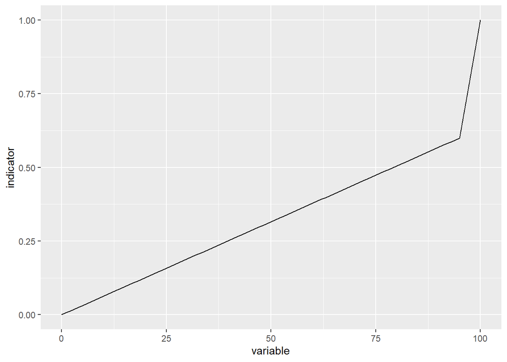

Figure 1: Normalisation function (piecewise linear)

```r
temp <- tibble(
  variable = as.numeric(),
  indicator = as.numeric()
)
ref <- 100
lim <- 95
maxmin <- 0


for(i in 0:100) {
  val <- i
  temp[i+1, "indicator"] <- scal()
  temp[i+1, "variable"] <- val
}

temp |>
  ggplot() +
  geom_line(aes(x = variable,
                 y = indicator))
```

We then can prepare a list of data frames to hold the results and perform the scaling according to the principles described in NINA report 1967 (Töpper and Jakobsson 2021).

```r
unique(ANO.geo$hovedoekosystem_250m2) # major ecosystem types in circle data
unique(ANO.geo$hovedoekosystem_rute) # major ecosystem types in circle data
#### creating dataframe to hold the results for wetlands ####
results.ANO.alien <- list()
results.ANO.alien[['original']] <- ANO.geo
# drop geometry
st_geometry(results.ANO.alien[['original']]) <- NULL
results.ANO.alien[['original']]
# add column for the indicator
results.ANO.alien[['original']][,'alien'] <- NA
results.ANO.alien[['original']][,'alien'] <- as.numeric(results.ANO.alien[['original']][,'alien'])
summary(results.ANO.alien[['original']])
results.ANO.alien[['original']]$globalid <- as.factor(results.ANO.alien[['original']]$globalid)
results.ANO.alien[['original']]$ano_flate_id <- as.factor(results.ANO.alien[['original']]$ano_flate_id)
results.ANO.alien[['original']]$ano_punkt_id <- as.factor(results.ANO.alien[['original']]$ano_punkt_id)
results.ANO.alien[['original']]$hovedoekosystem_250m2 <- as.factor(results.ANO.alien[['original']]$hovedoekosystem_250m2)
results.ANO.alien[['original']]$hovedoekosystem_rute  <- as.factor(results.ANO.alien[['original']]$hovedoekosystem_rute)
results.ANO.alien[['original']]$kartleggingsenhet_1m2 <- as.factor(results.ANO.alien[['original']]$kartleggingsenhet_1m2)
results.ANO.alien[['original']]$hovedtype_rute    <- as.factor(results.ANO.alien[['original']]$hovedtype_rute)


# roll out
results.ANO.alien[['scaled']] <- results.ANO.alien[['original']]
```

```r
#### calculating scaled and non-truncated values for the indicators based on the dataset ####
for (i in 1:nrow(ANO.geo) ) {  #
  tryCatch({
    print(i)
    print(paste(ANO.geo$ano_flate_id[i]))
    print(paste(ANO.geo$ano_punkt_id[i]))
    #    ANO.all$Hovedoekosystem_sirkel[i]
    #    ANO.all$Hovedoekosystem_rute[i]



        # Alien species evaluation
        val <- 100-ANO.geo$fremmedarter_total_dekning[i]

        if ( !is.na(val) ) {

          # scaling thresholds
          ref <- 100
          lim <- 95
          maxmin <- 0

          # coercing x into results.ANO dataframe
          results.ANO.alien[['scaled']][i,'alien'] <- scal()
          results.ANO.alien[['original']][i,'alien'] <- val

        }


  }, error=function(e){cat("ERROR :",conditionMessage(e), "\n")})
}


#saveRDS(results.ANO.alien, paste0(here::here(),"/indicators/NO_ALIE_002-005/data/cache/results.ANO.alien.RDS"))
```

#### Scaled value analyses

In order to calculate regional indices for the indicator(s) in addition to national ones we need to add information on region to the results-object.

```r
#### preparing results data for calculating of indices ####
## continuing with 2-sided
res.ANO.alien <- results.ANO.alien[['scaled']]

# add geometry again
st_geometry(res.ANO.alien) <- st_geometry(ANO.geo)

nor <- st_read(here::here("indicators/NO_ALIE_002-005/data/outlineOfNorway_EPSG25833.shp"),
               quiet = T)%>%
  st_as_sf() %>%
  st_transform(crs = sf::st_crs(ANO.geo))

reg <- st_read(here::here("indicators/NO_ALIE_002-005/data/regions.shp"),
               quiet = T) %>%
  st_as_sf() %>%
  st_transform(crs = sf::st_crs(ANO.geo))

# change region names to something R-friendly
# reg$region
reg$region <- c("Northern.Norway","Central.Norway","Eastern.Norway","Western.Norway","Southern.Norway")

regnor <- st_intersection(reg,nor)

res.ANO.alien = st_join(res.ANO.alien, regnor, left = TRUE)
```

### Calculating national and regional indices

We can calculate national and region-wise medians and 0.25 and 0.75 quantiles. Calculating means is not recommended since these data do not follow a Gaussian distribution. The national and regional estimates are computed separately (i.e. regional estimates are not spatially aggregated).

```r
# define quantiles
res.quant <- c(.25,.5,.75)

## forest ecosystems
# list to hold the results
NO_ALIE_004_2022to2024 <- data.frame(Indicator="alien",
                                     region=c("Norway", "Northern.Norway", "Central.Norway", "Western.Norway", "Eastern.Norway", "Southern.Norway"),
                                     median=NA,
                                     low=NA,
                                     high=NA,
                                     n=NA)
NO_ALIE_004_2019to2021 <- data.frame(Indicator="alien",
                                     region=c("Norway", "Northern.Norway", "Central.Norway", "Western.Norway", "Eastern.Norway", "Southern.Norway"),
                                     median=NA,
                                     low=NA,
                                     high=NA,
                                     n=NA)

# calculation of the median and quantiles
# Norway 2022-2024
df <- res.ANO.alien[(res.ANO.alien$hovedoekosystem_250m2=='skog' | res.ANO.alien$hovedoekosystem_rute=='Forest') & res.ANO.alien$aar %in% c(2022, 2023, 2024) ,c('ano_flate_id','region','hovedoekosystem_250m2','hovedoekosystem_rute','alien')]
res <-  quantile(df$alien,res.quant, na.rm=T)
NO_ALIE_004_2022to2024$low[1] <- res[1]
NO_ALIE_004_2022to2024$median[1] <- res[2]
NO_ALIE_004_2022to2024$high[1] <- res[3]
NO_ALIE_004_2022to2024$n[1] <- nrow(df[!is.na(df$alien),])
# regions 2022-2024
for (i in 2:6) {
  df <- res.ANO.alien[(res.ANO.alien$hovedoekosystem_250m2=='skog' | res.ANO.alien$hovedoekosystem_rute=='Forest') & res.ANO.alien$aar %in% c(2022, 2023, 2024) & res.ANO.alien$region==NO_ALIE_004_2022to2024$region[i], c('ano_flate_id','region','hovedoekosystem_250m2','hovedoekosystem_rute','alien')]
res <-  quantile(df$alien,res.quant, na.rm=T)
NO_ALIE_004_2022to2024$low[i] <- res[1]
NO_ALIE_004_2022to2024$median[i] <- res[2]
NO_ALIE_004_2022to2024$high[i] <- res[3]
NO_ALIE_004_2022to2024$n[i] <- nrow(df[!is.na(df$alien),])
}
# Norway 2019-2021
df <- res.ANO.alien[(res.ANO.alien$hovedoekosystem_250m2=='skog' | res.ANO.alien$hovedoekosystem_rute=='Forest') & res.ANO.alien$aar %in% c(2019, 2020, 2021) ,c('ano_flate_id','region','hovedoekosystem_250m2','hovedoekosystem_rute','alien')]
res <-  quantile(df$alien,res.quant, na.rm=T)
NO_ALIE_004_2019to2021$low[1] <- res[1]
NO_ALIE_004_2019to2021$median[1] <- res[2]
NO_ALIE_004_2019to2021$high[1] <- res[3]
NO_ALIE_004_2019to2021$n[1] <- nrow(df[!is.na(df$alien),])
# regions 2019-2021
for (i in 2:6) {
  df <- res.ANO.alien[(res.ANO.alien$hovedoekosystem_250m2=='skog' | res.ANO.alien$hovedoekosystem_rute=='Forest') & res.ANO.alien$aar %in% c(2019, 2020, 2021) & res.ANO.alien$region==NO_ALIE_004_2019to2021$region[i], c('ano_flate_id','region','hovedoekosystem_250m2','hovedoekosystem_rute','alien')]
res <-  quantile(df$alien,res.quant, na.rm=T)
NO_ALIE_004_2019to2021$low[i] <- res[1]
NO_ALIE_004_2019to2021$median[i] <- res[2]
NO_ALIE_004_2019to2021$high[i] <- res[3]
NO_ALIE_004_2019to2021$n[i] <- nrow(df[!is.na(df$alien),])
}


## mountain ecosystems
# list to hold the results
NO_ALIE_002_2022to2024 <- data.frame(Indicator="alien",
                                     region=c("Norway", "Northern.Norway", "Central.Norway", "Western.Norway", "Eastern.Norway", "Southern.Norway"),
                                     median=NA,
                                     low=NA,
                                     high=NA,
                                     n=NA)
NO_ALIE_002_2019to2021 <- data.frame(Indicator="alien",
                                     region=c("Norway", "Northern.Norway", "Central.Norway", "Western.Norway", "Eastern.Norway", "Southern.Norway"),
                                     median=NA,
                                     low=NA,
                                     high=NA,
                                     n=NA)

# calculation of the median and quantiles
# Norway 2022-2024
df <- res.ANO.alien[(res.ANO.alien$hovedoekosystem_250m2=='fjell' | res.ANO.alien$hovedoekosystem_rute=='Mountain') & res.ANO.alien$aar %in% c(2022, 2023, 2024) ,c('ano_flate_id','region','hovedoekosystem_250m2','hovedoekosystem_rute','alien')]
res <-  quantile(df$alien,res.quant, na.rm=T)
NO_ALIE_002_2022to2024$low[1] <- res[1]
NO_ALIE_002_2022to2024$median[1] <- res[2]
NO_ALIE_002_2022to2024$high[1] <- res[3]
NO_ALIE_002_2022to2024$n[1] <- nrow(df[!is.na(df$alien),])
# regions 2022-2024
for (i in 2:6) {
  df <- res.ANO.alien[(res.ANO.alien$hovedoekosystem_250m2=='fjell' | res.ANO.alien$hovedoekosystem_rute=='Mountain') & res.ANO.alien$aar %in% c(2022, 2023, 2024) & res.ANO.alien$region==NO_ALIE_002_2022to2024$region[i], c('ano_flate_id','region','hovedoekosystem_250m2','hovedoekosystem_rute','alien')]
res <-  quantile(df$alien,res.quant, na.rm=T)
NO_ALIE_002_2022to2024$low[i] <- res[1]
NO_ALIE_002_2022to2024$median[i] <- res[2]
NO_ALIE_002_2022to2024$high[i] <- res[3]
NO_ALIE_002_2022to2024$n[i] <- nrow(df[!is.na(df$alien),])
}
# Norway 2019-2021
df <- res.ANO.alien[(res.ANO.alien$hovedoekosystem_250m2=='fjell' | res.ANO.alien$hovedoekosystem_rute=='Mountain') & res.ANO.alien$aar %in% c(2019, 2020, 2021) ,c('ano_flate_id','region','hovedoekosystem_250m2','hovedoekosystem_rute','alien')]
res <-  quantile(df$alien,res.quant, na.rm=T)
NO_ALIE_002_2019to2021$low[1] <- res[1]
NO_ALIE_002_2019to2021$median[1] <- res[2]
NO_ALIE_002_2019to2021$high[1] <- res[3]
NO_ALIE_002_2019to2021$n[1] <- nrow(df[!is.na(df$alien),])
# regions 2019-2021
for (i in 2:6) {
  df <- res.ANO.alien[(res.ANO.alien$hovedoekosystem_250m2=='fjell' | res.ANO.alien$hovedoekosystem_rute=='Mountain') & res.ANO.alien$aar %in% c(2019, 2020, 2021) & res.ANO.alien$region==NO_ALIE_002_2019to2021$region[i], c('ano_flate_id','region','hovedoekosystem_250m2','hovedoekosystem_rute','alien')]
res <-  quantile(df$alien,res.quant, na.rm=T)
NO_ALIE_002_2019to2021$low[i] <- res[1]
NO_ALIE_002_2019to2021$median[i] <- res[2]
NO_ALIE_002_2019to2021$high[i] <- res[3]
NO_ALIE_002_2019to2021$n[i] <- nrow(df[!is.na(df$alien),])
}
```

```r
## wetland ecosystems
# list to hold the results
NO_ALIE_003_2022to2024 <- data.frame(Indicator="alien",
                                     region=c("Norway", "Northern.Norway", "Central.Norway", "Western.Norway", "Eastern.Norway", "Southern.Norway"),
                                     median=NA,
                                     low=NA,
                                     high=NA,
                                     n=NA)
NO_ALIE_003_2019to2021 <- data.frame(Indicator="alien",
                                     region=c("Norway", "Northern.Norway", "Central.Norway", "Western.Norway", "Eastern.Norway", "Southern.Norway"),
                                     median=NA,
                                     low=NA,
                                     high=NA,
                                     n=NA)

# calculation of the median and quantiles
# Norway 2022-2024
df <- res.ANO.alien[(res.ANO.alien$hovedoekosystem_250m2=='vaatmark' | res.ANO.alien$hovedoekosystem_rute=='Wetland') & res.ANO.alien$aar %in% c(2022, 2023, 2024) ,c('ano_flate_id','region','hovedoekosystem_250m2','hovedoekosystem_rute','alien')]
res <-  quantile(df$alien,res.quant, na.rm=T)
NO_ALIE_003_2022to2024$low[1] <- res[1]
NO_ALIE_003_2022to2024$median[1] <- res[2]
NO_ALIE_003_2022to2024$high[1] <- res[3]
NO_ALIE_003_2022to2024$n[1] <- nrow(df[!is.na(df$alien),])
# regions 2022-2024
for (i in 2:6) {
  df <- res.ANO.alien[(res.ANO.alien$hovedoekosystem_250m2=='vaatmark' | res.ANO.alien$hovedoekosystem_rute=='Wetland') & res.ANO.alien$aar %in% c(2022, 2023, 2024) & res.ANO.alien$region==NO_ALIE_003_2022to2024$region[i], c('ano_flate_id','region','hovedoekosystem_250m2','hovedoekosystem_rute','alien')]
res <-  quantile(df$alien,res.quant, na.rm=T)
NO_ALIE_003_2022to2024$low[i] <- res[1]
NO_ALIE_003_2022to2024$median[i] <- res[2]
NO_ALIE_003_2022to2024$high[i] <- res[3]
NO_ALIE_003_2022to2024$n[i] <- nrow(df[!is.na(df$alien),])
}
# Norway 2019-2021
df <- res.ANO.alien[(res.ANO.alien$hovedoekosystem_250m2=='vaatmark' | res.ANO.alien$hovedoekosystem_rute=='Wetland') & res.ANO.alien$aar %in% c(2019, 2020, 2021) ,c('ano_flate_id','region','hovedoekosystem_250m2','hovedoekosystem_rute','alien')]
res <-  quantile(df$alien,res.quant, na.rm=T)
NO_ALIE_003_2019to2021$low[1] <- res[1]
NO_ALIE_003_2019to2021$median[1] <- res[2]
NO_ALIE_003_2019to2021$high[1] <- res[3]
NO_ALIE_003_2019to2021$n[1] <- nrow(df[!is.na(df$alien),])
# regions 2019-2021
for (i in 2:6) {
  df <- res.ANO.alien[(res.ANO.alien$hovedoekosystem_250m2=='vaatmark' | res.ANO.alien$hovedoekosystem_rute=='Wetland') & res.ANO.alien$aar %in% c(2019, 2020, 2021) & res.ANO.alien$region==NO_ALIE_003_2019to2021$region[i], c('ano_flate_id','region','hovedoekosystem_250m2','hovedoekosystem_rute','alien')]
res <-  quantile(df$alien,res.quant, na.rm=T)
NO_ALIE_003_2019to2021$low[i] <- res[1]
NO_ALIE_003_2019to2021$median[i] <- res[2]
NO_ALIE_003_2019to2021$high[i] <- res[3]
NO_ALIE_003_2019to2021$n[i] <- nrow(df[!is.na(df$alien),])
}


## open lowland ecosystems
# list to hold the results
NO_ALIE_005_2022to2024 <- data.frame(Indicator="alien",
                                     region=c("Norway", "Northern.Norway", "Central.Norway", "Western.Norway", "Eastern.Norway", "Southern.Norway"),
                                     median=NA,
                                     low=NA,
                                     high=NA,
                                     n=NA)
NO_ALIE_005_2019to2021 <- data.frame(Indicator="alien",
                                     region=c("Norway", "Northern.Norway", "Central.Norway", "Western.Norway", "Eastern.Norway", "Southern.Norway"),
                                     median=NA,
                                     low=NA,
                                     high=NA,
                                     n=NA)

# calculation of the median and quantiles
# Norway 2022-2024
df <- res.ANO.alien[(res.ANO.alien$hovedoekosystem_250m2  %in% c("naturlig_apne","semi_naturlig_mark") | res.ANO.alien$hovedoekosystem_rute %in% c("Seminat","Natopen") | res.ANO.alien$hovedtype_rute %in% c('T40','T41')) & res.ANO.alien$aar %in% c(2022, 2023, 2024) ,c('ano_flate_id','region','hovedoekosystem_250m2','hovedoekosystem_rute','alien')]
res <-  quantile(df$alien,res.quant, na.rm=T)
NO_ALIE_005_2022to2024$low[1] <- res[1]
NO_ALIE_005_2022to2024$median[1] <- res[2]
NO_ALIE_005_2022to2024$high[1] <- res[3]
NO_ALIE_005_2022to2024$n[1] <- nrow(df[!is.na(df$alien),])
# regions 2022-2024
for (i in 2:6) {
  df <- res.ANO.alien[(res.ANO.alien$hovedoekosystem_250m2  %in% c("naturlig_apne","semi_naturlig_mark") | res.ANO.alien$hovedoekosystem_rute %in% c("Seminat","Natopen") | res.ANO.alien$hovedtype_rute %in% c('T40','T41')) & res.ANO.alien$aar %in% c(2022, 2023, 2024) & res.ANO.alien$region==NO_ALIE_005_2022to2024$region[i], c('ano_flate_id','region','hovedoekosystem_250m2','hovedoekosystem_rute','alien')]
res <-  quantile(df$alien,res.quant, na.rm=T)
NO_ALIE_005_2022to2024$low[i] <- res[1]
NO_ALIE_005_2022to2024$median[i] <- res[2]
NO_ALIE_005_2022to2024$high[i] <- res[3]
NO_ALIE_005_2022to2024$n[i] <- nrow(df[!is.na(df$alien),])
}
# Norway 2019-2021
df <- res.ANO.alien[(res.ANO.alien$hovedoekosystem_250m2  %in% c("naturlig_apne","semi_naturlig_mark") | res.ANO.alien$hovedoekosystem_rute %in% c("Seminat","Natopen") | res.ANO.alien$hovedtype_rute %in% c('T40','T41')) & res.ANO.alien$aar %in% c(2019, 2020, 2021) ,c('ano_flate_id','region','hovedoekosystem_250m2','hovedoekosystem_rute','alien')]
res <-  quantile(df$alien,res.quant, na.rm=T)
NO_ALIE_005_2019to2021$low[1] <- res[1]
NO_ALIE_005_2019to2021$median[1] <- res[2]
NO_ALIE_005_2019to2021$high[1] <- res[3]
NO_ALIE_005_2019to2021$n[1] <- nrow(df[!is.na(df$alien),])
# regions 2019-2021
for (i in 2:6) {
  df <- res.ANO.alien[(res.ANO.alien$hovedoekosystem_250m2  %in% c("naturlig_apne","semi_naturlig_mark") | res.ANO.alien$hovedoekosystem_rute %in% c("Seminat","Natopen") | res.ANO.alien$hovedtype_rute %in% c('T40','T41')) & res.ANO.alien$aar %in% c(2019, 2020, 2021) & res.ANO.alien$region==NO_ALIE_005_2019to2021$region[i], c('ano_flate_id','region','hovedoekosystem_250m2','hovedoekosystem_rute','alien')]
res <-  quantile(df$alien,res.quant, na.rm=T)
NO_ALIE_005_2019to2021$low[i] <- res[1]
NO_ALIE_005_2019to2021$median[i] <- res[2]
NO_ALIE_005_2019to2021$high[i] <- res[3]
NO_ALIE_005_2019to2021$n[i] <- nrow(df[!is.na(df$alien),])
}
```

```r
## naturally open lowland ecosystems
# list to hold the results
NO_ALIE_005a_2022to2024 <- data.frame(Indicator="alien",
                                     region=c("Norway", "Northern.Norway", "Central.Norway", "Western.Norway", "Eastern.Norway", "Southern.Norway"),
                                     median=NA,
                                     low=NA,
                                     high=NA,
                                     n=NA)
NO_ALIE_005a_2019to2021 <- data.frame(Indicator="alien",
                                     region=c("Norway", "Northern.Norway", "Central.Norway", "Western.Norway", "Eastern.Norway", "Southern.Norway"),
                                     median=NA,
                                     low=NA,
                                     high=NA,
                                     n=NA)

# calculation of the median and quantiles
# Norway 2022-2024
df <- res.ANO.alien[(res.ANO.alien$hovedoekosystem_250m2  %in% c("naturlig_apne") | res.ANO.alien$hovedoekosystem_rute %in% c("Natopen")) & res.ANO.alien$aar %in% c(2022, 2023, 2024) ,c('ano_flate_id','region','hovedoekosystem_250m2','hovedoekosystem_rute','alien')]
res <-  quantile(df$alien,res.quant, na.rm=T)
NO_ALIE_005a_2022to2024$low[1] <- res[1]
NO_ALIE_005a_2022to2024$median[1] <- res[2]
NO_ALIE_005a_2022to2024$high[1] <- res[3]
NO_ALIE_005a_2022to2024$n[1] <- nrow(df[!is.na(df$alien),])
# regions 2022-2024
for (i in 2:6) {
  df <- res.ANO.alien[(res.ANO.alien$hovedoekosystem_250m2  %in% c("naturlig_apne") | res.ANO.alien$hovedoekosystem_rute %in% c("Natopen")) & res.ANO.alien$aar %in% c(2022, 2023, 2024) & res.ANO.alien$region==NO_ALIE_005a_2022to2024$region[i], c('ano_flate_id','region','hovedoekosystem_250m2','hovedoekosystem_rute','alien')]
res <-  quantile(df$alien,res.quant, na.rm=T)
NO_ALIE_005a_2022to2024$low[i] <- res[1]
NO_ALIE_005a_2022to2024$median[i] <- res[2]
NO_ALIE_005a_2022to2024$high[i] <- res[3]
NO_ALIE_005a_2022to2024$n[i] <- nrow(df[!is.na(df$alien),])
}
# Norway 2019-2021
df <- res.ANO.alien[(res.ANO.alien$hovedoekosystem_250m2  %in% c("naturlig_apne") | res.ANO.alien$hovedoekosystem_rute %in% c("Natopen")) & res.ANO.alien$aar %in% c(2019, 2020, 2021) ,c('ano_flate_id','region','hovedoekosystem_250m2','hovedoekosystem_rute','alien')]
res <-  quantile(df$alien,res.quant, na.rm=T)
NO_ALIE_005a_2019to2021$low[1] <- res[1]
NO_ALIE_005a_2019to2021$median[1] <- res[2]
NO_ALIE_005a_2019to2021$high[1] <- res[3]
NO_ALIE_005a_2019to2021$n[1] <- nrow(df[!is.na(df$alien),])
# regions 2019-2021
for (i in 2:6) {
  df <- res.ANO.alien[(res.ANO.alien$hovedoekosystem_250m2  %in% c("naturlig_apne") | res.ANO.alien$hovedoekosystem_rute %in% c("Natopen")) & res.ANO.alien$aar %in% c(2019, 2020, 2021) & res.ANO.alien$region==NO_ALIE_005a_2019to2021$region[i], c('ano_flate_id','region','hovedoekosystem_250m2','hovedoekosystem_rute','alien')]
res <-  quantile(df$alien,res.quant, na.rm=T)
NO_ALIE_005a_2019to2021$low[i] <- res[1]
NO_ALIE_005a_2019to2021$median[i] <- res[2]
NO_ALIE_005a_2019to2021$high[i] <- res[3]
NO_ALIE_005a_2019to2021$n[i] <- nrow(df[!is.na(df$alien),])
}


## semi-natural ecosystems
# list to hold the results
NO_ALIE_005b_2022to2024 <- data.frame(Indicator="alien",
                                     region=c("Norway", "Northern.Norway", "Central.Norway", "Western.Norway", "Eastern.Norway", "Southern.Norway"),
                                     median=NA,
                                     low=NA,
                                     high=NA,
                                     n=NA)
NO_ALIE_005b_2019to2021 <- data.frame(Indicator="alien",
                                     region=c("Norway", "Northern.Norway", "Central.Norway", "Western.Norway", "Eastern.Norway", "Southern.Norway"),
                                     median=NA,
                                     low=NA,
                                     high=NA,
                                     n=NA)

# calculation of the median and quantiles
# Norway 2022-2024
df <- res.ANO.alien[(res.ANO.alien$hovedoekosystem_250m2  %in% c("semi_naturlig_mark") | res.ANO.alien$hovedoekosystem_rute %in% c("Seminat") | res.ANO.alien$hovedtype_rute %in% c('T40','T41')) & res.ANO.alien$aar %in% c(2022, 2023, 2024) ,c('ano_flate_id','region','hovedoekosystem_250m2','hovedoekosystem_rute','alien')]
res <-  quantile(df$alien,res.quant, na.rm=T)
NO_ALIE_005b_2022to2024$low[1] <- res[1]
NO_ALIE_005b_2022to2024$median[1] <- res[2]
NO_ALIE_005b_2022to2024$high[1] <- res[3]
NO_ALIE_005b_2022to2024$n[1] <- nrow(df[!is.na(df$alien),])
# regions 2022-2024
for (i in 2:6) {
  df <- res.ANO.alien[(res.ANO.alien$hovedoekosystem_250m2  %in% c("semi_naturlig_mark") | res.ANO.alien$hovedoekosystem_rute %in% c("Seminat") | res.ANO.alien$hovedtype_rute %in% c('T40','T41')) & res.ANO.alien$aar %in% c(2022, 2023, 2024) & res.ANO.alien$region==NO_ALIE_005b_2022to2024$region[i], c('ano_flate_id','region','hovedoekosystem_250m2','hovedoekosystem_rute','alien')]
res <-  quantile(df$alien,res.quant, na.rm=T)
NO_ALIE_005b_2022to2024$low[i] <- res[1]
NO_ALIE_005b_2022to2024$median[i] <- res[2]
NO_ALIE_005b_2022to2024$high[i] <- res[3]
NO_ALIE_005b_2022to2024$n[i] <- nrow(df[!is.na(df$alien),])
}
# Norway 2019-2021
df <- res.ANO.alien[(res.ANO.alien$hovedoekosystem_250m2  %in% c("semi_naturlig_mark") | res.ANO.alien$hovedoekosystem_rute %in% c("Seminat") | res.ANO.alien$hovedtype_rute %in% c('T40','T41')) & res.ANO.alien$aar %in% c(2019, 2020, 2021) ,c('ano_flate_id','region','hovedoekosystem_250m2','hovedoekosystem_rute','alien')]
res <-  quantile(df$alien,res.quant, na.rm=T)
NO_ALIE_005b_2019to2021$low[1] <- res[1]
NO_ALIE_005b_2019to2021$median[1] <- res[2]
NO_ALIE_005b_2019to2021$high[1] <- res[3]
NO_ALIE_005b_2019to2021$n[1] <- nrow(df[!is.na(df$alien),])
# regions 2019-2021
for (i in 2:6) {
  df <- res.ANO.alien[(res.ANO.alien$hovedoekosystem_250m2  %in% c("naturlig_apne","semi_naturlig_mark") | res.ANO.alien$hovedoekosystem_rute %in% c("Seminat","Natopen") | res.ANO.alien$hovedtype_rute %in% c('T40','T41')) & res.ANO.alien$aar %in% c(2019, 2020, 2021) & res.ANO.alien$region==NO_ALIE_005b_2019to2021$region[i], c('ano_flate_id','region','hovedoekosystem_250m2','hovedoekosystem_rute','alien')]
res <-  quantile(df$alien,res.quant, na.rm=T)
NO_ALIE_005b_2019to2021$low[i] <- res[1]
NO_ALIE_005b_2019to2021$median[i] <- res[2]
NO_ALIE_005b_2019to2021$high[i] <- res[3]
NO_ALIE_005b_2019to2021$n[i] <- nrow(df[!is.na(df$alien),])
}
```

## 10. Results

The results are shown in Table 2. Although there are some ANO sites with alien plant species, the aggregated indicator values (medians and quartiles) are consistently 1.

```r
### median indicator values for 'Alien plant species', lower and upper prediction intervals (low, high), and number of observations (n)

# open lowland (natopen & seminat combined)
bind_rows(
  NO_ALIE_005_2022to2024 |> mutate(Indicator = "NO_ALIE_005", years = "2022-2024", ecosystem = "Open lowland"),
  NO_ALIE_005_2019to2021 |> mutate(Indicator = "NO_ALIE_005", years = "2019-2021", ecosystem = "Open lowland"),
# natopen
  NO_ALIE_005a_2022to2024 |> mutate(Indicator = "NO_ALIE_005a", years = "2022-2024", ecosystem = "Naturally open ecosystems"),
  NO_ALIE_005a_2019to2021 |> mutate(Indicator = "NO_ALIE_005a", years = "2019-2021", ecosystem = "Naturally open ecosystems"),
# seminat
  NO_ALIE_005b_2022to2024 |> mutate(Indicator = "NO_ALIE_005b", years = "2022-2024", ecosystem = "Semi-natural ecosystems"),
  NO_ALIE_005b_2019to2021 |> mutate(Indicator = "NO_ALIE_005b", years = "2019-2021", ecosystem = "Semi-natural ecosystems"),
# mountain ecosystems
  NO_ALIE_002_2022to2024 |> mutate(Indicator = "NO_ALIE_002", years = "2022-2024", ecosystem = "Mountains"),
  NO_ALIE_002_2019to2021 |> mutate(Indicator = "NO_ALIE_002", years = "2019-2021", ecosystem = "Mountains"),
# wetland ecosystems
  NO_ALIE_003_2022to2024 |> mutate(Indicator = "NO_ALIE_003", years = "2022-2024", ecosystem = "Wetlands"),
  NO_ALIE_003_2019to2021 |> mutate(Indicator = "NO_ALIE_003", years = "2019-2021", ecosystem = "Wetlands"),
# forest ecosystems
  NO_ALIE_004_2022to2024 |> mutate(Indicator = "NO_ALIE_004", years = "2022-2024", ecosystem = "Forest"),
  NO_ALIE_004_2019to2021 |> mutate(Indicator = "NO_ALIE_004", years = "2019-2021", ecosystem = "Forest")) |>
  kbl()
```

Table 2: Indicator values for the indicator Alien plant species.

| Indicator | region | median | low | high | n | years | ecosystem |
| --- | --- | --- | --- | --- | --- | --- | --- |
| NO_ALIE_005 | Norway | 1 | 1 | 1 | 702 | 2022-2024 | Open lowland |
| NO_ALIE_005 | Northern.Norway | 1 | 1 | 1 | 205 | 2022-2024 | Open lowland |
| NO_ALIE_005 | Central.Norway | 1 | 1 | 1 | 118 | 2022-2024 | Open lowland |
| NO_ALIE_005 | Western.Norway | 1 | 1 | 1 | 162 | 2022-2024 | Open lowland |
| NO_ALIE_005 | Eastern.Norway | 1 | 1 | 1 | 132 | 2022-2024 | Open lowland |
| NO_ALIE_005 | Southern.Norway | 1 | 1 | 1 | 79 | 2022-2024 | Open lowland |
| NO_ALIE_005 | Norway | 1 | 1 | 1 | 796 | 2019-2021 | Open lowland |
| NO_ALIE_005 | Northern.Norway | 1 | 1 | 1 | 258 | 2019-2021 | Open lowland |
| NO_ALIE_005 | Central.Norway | 1 | 1 | 1 | 139 | 2019-2021 | Open lowland |
| NO_ALIE_005 | Western.Norway | 1 | 1 | 1 | 214 | 2019-2021 | Open lowland |
| NO_ALIE_005 | Eastern.Norway | 1 | 1 | 1 | 131 | 2019-2021 | Open lowland |
| NO_ALIE_005 | Southern.Norway | 1 | 1 | 1 | 53 | 2019-2021 | Open lowland |
| NO_ALIE_005a | Norway | 1 | 1 | 1 | 403 | 2022-2024 | Naturally open ecosystems |
| NO_ALIE_005a | Northern.Norway | 1 | 1 | 1 | 122 | 2022-2024 | Naturally open ecosystems |
| NO_ALIE_005a | Central.Norway | 1 | 1 | 1 | 51 | 2022-2024 | Naturally open ecosystems |
| NO_ALIE_005a | Western.Norway | 1 | 1 | 1 | 118 | 2022-2024 | Naturally open ecosystems |
| NO_ALIE_005a | Eastern.Norway | 1 | 1 | 1 | 41 | 2022-2024 | Naturally open ecosystems |
| NO_ALIE_005a | Southern.Norway | 1 | 1 | 1 | 65 | 2022-2024 | Naturally open ecosystems |
| NO_ALIE_005a | Norway | 1 | 1 | 1 | 314 | 2019-2021 | Naturally open ecosystems |
| NO_ALIE_005a | Northern.Norway | 1 | 1 | 1 | 85 | 2019-2021 | Naturally open ecosystems |
| NO_ALIE_005a | Central.Norway | 1 | 1 | 1 | 59 | 2019-2021 | Naturally open ecosystems |
| NO_ALIE_005a | Western.Norway | 1 | 1 | 1 | 114 | 2019-2021 | Naturally open ecosystems |
| NO_ALIE_005a | Eastern.Norway | 1 | 1 | 1 | 27 | 2019-2021 | Naturally open ecosystems |
| NO_ALIE_005a | Southern.Norway | 1 | 1 | 1 | 29 | 2019-2021 | Naturally open ecosystems |
| NO_ALIE_005b | Norway | 1 | 1 | 1 | 329 | 2022-2024 | Semi-natural ecosystems |
| NO_ALIE_005b | Northern.Norway | 1 | 1 | 1 | 89 | 2022-2024 | Semi-natural ecosystems |
| NO_ALIE_005b | Central.Norway | 1 | 1 | 1 | 78 | 2022-2024 | Semi-natural ecosystems |
| NO_ALIE_005b | Western.Norway | 1 | 1 | 1 | 45 | 2022-2024 | Semi-natural ecosystems |
| NO_ALIE_005b | Eastern.Norway | 1 | 1 | 1 | 102 | 2022-2024 | Semi-natural ecosystems |
| NO_ALIE_005b | Southern.Norway | 1 | 1 | 1 | 15 | 2022-2024 | Semi-natural ecosystems |
| NO_ALIE_005b | Norway | 1 | 1 | 1 | 487 | 2019-2021 | Semi-natural ecosystems |
| NO_ALIE_005b | Northern.Norway | 1 | 1 | 1 | 258 | 2019-2021 | Semi-natural ecosystems |
| NO_ALIE_005b | Central.Norway | 1 | 1 | 1 | 139 | 2019-2021 | Semi-natural ecosystems |
| NO_ALIE_005b | Western.Norway | 1 | 1 | 1 | 214 | 2019-2021 | Semi-natural ecosystems |
| NO_ALIE_005b | Eastern.Norway | 1 | 1 | 1 | 131 | 2019-2021 | Semi-natural ecosystems |
| NO_ALIE_005b | Southern.Norway | 1 | 1 | 1 | 53 | 2019-2021 | Semi-natural ecosystems |
| NO_ALIE_002 | Norway | 1 | 1 | 1 | 4012 | 2022-2024 | Mountains |
| NO_ALIE_002 | Northern.Norway | 1 | 1 | 1 | 2119 | 2022-2024 | Mountains |
| NO_ALIE_002 | Central.Norway | 1 | 1 | 1 | 549 | 2022-2024 | Mountains |
| NO_ALIE_002 | Western.Norway | 1 | 1 | 1 | 598 | 2022-2024 | Mountains |
| NO_ALIE_002 | Eastern.Norway | 1 | 1 | 1 | 511 | 2022-2024 | Mountains |
| NO_ALIE_002 | Southern.Norway | 1 | 1 | 1 | 231 | 2022-2024 | Mountains |
| NO_ALIE_002 | Norway | 1 | 1 | 1 | 2465 | 2019-2021 | Mountains |
| NO_ALIE_002 | Northern.Norway | 1 | 1 | 1 | 1238 | 2019-2021 | Mountains |
| NO_ALIE_002 | Central.Norway | 1 | 1 | 1 | 342 | 2019-2021 | Mountains |
| NO_ALIE_002 | Western.Norway | 1 | 1 | 1 | 330 | 2019-2021 | Mountains |
| NO_ALIE_002 | Eastern.Norway | 1 | 1 | 1 | 482 | 2019-2021 | Mountains |
| NO_ALIE_002 | Southern.Norway | 1 | 1 | 1 | 71 | 2019-2021 | Mountains |
| NO_ALIE_003 | Norway | 1 | 1 | 1 | 1844 | 2022-2024 | Wetlands |
| NO_ALIE_003 | Northern.Norway | 1 | 1 | 1 | 534 | 2022-2024 | Wetlands |
| NO_ALIE_003 | Central.Norway | 1 | 1 | 1 | 658 | 2022-2024 | Wetlands |
| NO_ALIE_003 | Western.Norway | 1 | 1 | 1 | 137 | 2022-2024 | Wetlands |
| NO_ALIE_003 | Eastern.Norway | 1 | 1 | 1 | 392 | 2022-2024 | Wetlands |
| NO_ALIE_003 | Southern.Norway | 1 | 1 | 1 | 123 | 2022-2024 | Wetlands |
| NO_ALIE_003 | Norway | 1 | 1 | 1 | 1385 | 2019-2021 | Wetlands |
| NO_ALIE_003 | Northern.Norway | 1 | 1 | 1 | 427 | 2019-2021 | Wetlands |
| NO_ALIE_003 | Central.Norway | 1 | 1 | 1 | 365 | 2019-2021 | Wetlands |
| NO_ALIE_003 | Western.Norway | 1 | 1 | 1 | 158 | 2019-2021 | Wetlands |
| NO_ALIE_003 | Eastern.Norway | 1 | 1 | 1 | 304 | 2019-2021 | Wetlands |
| NO_ALIE_003 | Southern.Norway | 1 | 1 | 1 | 130 | 2019-2021 | Wetlands |
| NO_ALIE_004 | Norway | 1 | 1 | 1 | 3572 | 2022-2024 | Forest |
| NO_ALIE_004 | Northern.Norway | 1 | 1 | 1 | 763 | 2022-2024 | Forest |
| NO_ALIE_004 | Central.Norway | 1 | 1 | 1 | 889 | 2022-2024 | Forest |
| NO_ALIE_004 | Western.Norway | 1 | 1 | 1 | 206 | 2022-2024 | Forest |
| NO_ALIE_004 | Eastern.Norway | 1 | 1 | 1 | 1222 | 2022-2024 | Forest |
| NO_ALIE_004 | Southern.Norway | 1 | 1 | 1 | 477 | 2022-2024 | Forest |
| NO_ALIE_004 | Norway | 1 | 1 | 1 | 3003 | 2019-2021 | Forest |
| NO_ALIE_004 | Northern.Norway | 1 | 1 | 1 | 781 | 2019-2021 | Forest |
| NO_ALIE_004 | Central.Norway | 1 | 1 | 1 | 491 | 2019-2021 | Forest |
| NO_ALIE_004 | Western.Norway | 1 | 1 | 1 | 246 | 2019-2021 | Forest |
| NO_ALIE_004 | Eastern.Norway | 1 | 1 | 1 | 995 | 2019-2021 | Forest |
| NO_ALIE_004 | Southern.Norway | 1 | 1 | 1 | 488 | 2019-2021 | Forest |